# Testing AGAIN

# Tab 1: Bella’s part

# Tab 2: Mythili’s part

```r
path_mythili <- "C:/Users/seshu/Documents/RStudio/projects/git/Blog-HealthAndJusticeLeague/data"

#loading data
data_cluster1980s <- read_csv(paste0(path_mythili,"/wrangled_infmatmortcluster1980s.csv")) %>%
  mutate_at(c("avginfmort", "avmatmort"), funs(`std`=scale(.) %>% as.vector()))
#making cluster reproducible, setting number of clusters
set.seed(23)
km_out <- kmeans(data_cluster1980s[,c("avginfmort_std", "avmatmort_std")], centers=4, nstart=20)
```

[output not shown]

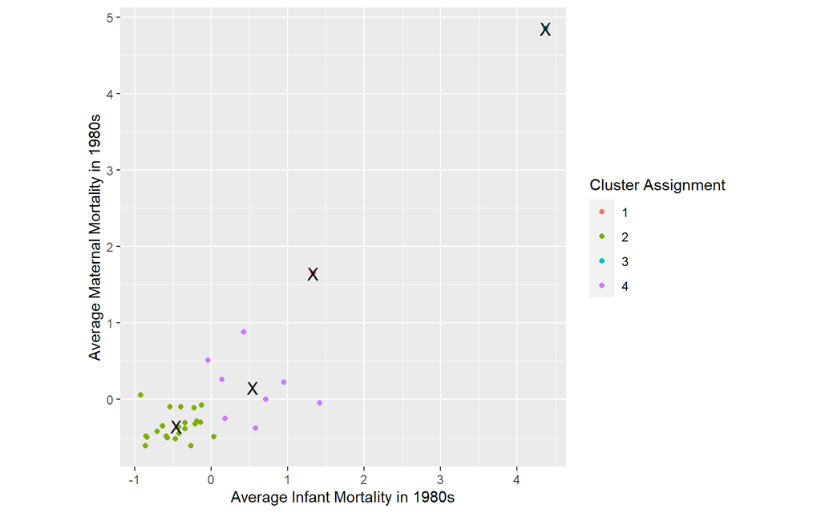

```r
# visualize the cluster assignments and centroids
ggplot(data = cluster1980s, aes(x = avginfmort_std, y = avmatmort_std)) +
  geom_point(aes(color = clust)) +
  #geom_text_repel(aes(label= `Country`, color = clust), size = 3) +
  coord_fixed() +
  geom_point(data = as.data.frame(km_out$centers)
             , aes(x = avginfmort_std, y = avmatmort_std)
             , pch = "X"
             , size = 4) +
  labs(x = "Average Infant Mortality in 1980s"
       , y = "Average Maternal Mortality in 1980s"
       , color = "Cluster Assignment")
```

# Tab 3: Lillian’s part